# Risk Factor Analysis

## Outcome Variable

**Outcome Variable:** pers_wasted624

## Predictor Variables

**Intervention Variable:** ever_swasted06

**Adjustment Set:**

- sex
- arm
- enstunt
- month
- brthmon
- vagbrth
- single
- W_gagebrth
- W_birthwt
- W_birthlen
- W_mage
- W_mhtcm
- W_meducyrs
- W_feducyrs
- W_parity
- delta_month
- delta_brthmon
- delta_vagbrth
- delta_single
- delta_W_gagebrth
- delta_W_birthwt
- delta_W_birthlen
- delta_W_mage
- delta_W_mhtcm
- delta_W_meducyrs
- delta_W_feducyrs
- delta_W_parity

## Stratifying Variables

The analysis was stratified on these variable(s):

- studyid
- country

## Data Summary

| studyid | country | ever_swasted06 | pers_wasted624 | n_cell | n |
| --- | --- | --- | --- | --- | --- |
| ki0047075b-MAL-ED | BANGLADESH | 0 | 0 | 209 | 239 |
| ki0047075b-MAL-ED | BANGLADESH | 0 | 1 | 14 | 239 |
| ki0047075b-MAL-ED | BANGLADESH | 1 | 0 | 12 | 239 |
| ki0047075b-MAL-ED | BANGLADESH | 1 | 1 | 4 | 239 |
| ki0047075b-MAL-ED | BRAZIL | 0 | 0 | 198 | 202 |
| ki0047075b-MAL-ED | BRAZIL | 0 | 1 | 2 | 202 |
| ki0047075b-MAL-ED | BRAZIL | 1 | 0 | 2 | 202 |
| ki0047075b-MAL-ED | BRAZIL | 1 | 1 | 0 | 202 |
| ki0047075b-MAL-ED | INDIA | 0 | 0 | 197 | 234 |
| ki0047075b-MAL-ED | INDIA | 0 | 1 | 18 | 234 |
| ki0047075b-MAL-ED | INDIA | 1 | 0 | 9 | 234 |
| ki0047075b-MAL-ED | INDIA | 1 | 1 | 10 | 234 |
| ki0047075b-MAL-ED | NEPAL | 0 | 0 | 226 | 234 |
| ki0047075b-MAL-ED | NEPAL | 0 | 1 | 1 | 234 |
| ki0047075b-MAL-ED | NEPAL | 1 | 0 | 6 | 234 |
| ki0047075b-MAL-ED | NEPAL | 1 | 1 | 1 | 234 |
| ki0047075b-MAL-ED | PERU | 0 | 0 | 261 | 264 |
| ki0047075b-MAL-ED | PERU | 0 | 1 | 2 | 264 |
| ki0047075b-MAL-ED | PERU | 1 | 0 | 1 | 264 |
| ki0047075b-MAL-ED | PERU | 1 | 1 | 0 | 264 |
| ki0047075b-MAL-ED | SOUTH AFRICA | 0 | 0 | 252 | 258 |
| ki0047075b-MAL-ED | SOUTH AFRICA | 0 | 1 | 2 | 258 |
| ki0047075b-MAL-ED | SOUTH AFRICA | 1 | 0 | 4 | 258 |
| ki0047075b-MAL-ED | SOUTH AFRICA | 1 | 1 | 0 | 258 |
| ki0047075b-MAL-ED | TANZANIA, UNITED REPUBLIC OF | 0 | 0 | 241 | 244 |
| ki0047075b-MAL-ED | TANZANIA, UNITED REPUBLIC OF | 0 | 1 | 0 | 244 |
| ki0047075b-MAL-ED | TANZANIA, UNITED REPUBLIC OF | 1 | 0 | 3 | 244 |
| ki0047075b-MAL-ED | TANZANIA, UNITED REPUBLIC OF | 1 | 1 | 0 | 244 |
| ki1000108-CMC-V-BCS-2002 | INDIA | 0 | 0 | 282 | 368 |
| ki1000108-CMC-V-BCS-2002 | INDIA | 0 | 1 | 16 | 368 |

[output cut: 118 more lines]

The following strata were considered:

- studyid: ki0047075b-MAL-ED, country: BANGLADESH
- studyid: ki0047075b-MAL-ED, country: BRAZIL
- studyid: ki0047075b-MAL-ED, country: INDIA
- studyid: ki0047075b-MAL-ED, country: NEPAL
- studyid: ki0047075b-MAL-ED, country: PERU
- studyid: ki0047075b-MAL-ED, country: SOUTH AFRICA
- studyid: ki0047075b-MAL-ED, country: TANZANIA, UNITED REPUBLIC OF
- studyid: ki1000108-CMC-V-BCS-2002, country: INDIA
- studyid: ki1000108-IRC, country: INDIA
- studyid: ki1000109-EE, country: PAKISTAN
- studyid: ki1000109-ResPak, country: PAKISTAN
- studyid: ki1000304-VITAMIN-A, country: INDIA
- studyid: ki1000304b-SAS-CompFeed, country: INDIA
- studyid: ki1000304b-SAS-FoodSuppl, country: INDIA
- studyid: ki1017093-NIH-Birth, country: BANGLADESH
- studyid: ki1017093b-PROVIDE, country: BANGLADESH
- studyid: ki1017093c-NIH-Crypto, country: BANGLADESH
- studyid: ki1066203-TanzaniaChild2, country: TANZANIA, UNITED REPUBLIC OF
- studyid: ki1101329-Keneba, country: GAMBIA
- studyid: ki1112895-Burkina Faso Zn, country: BURKINA FASO
- studyid: ki1112895-Guatemala BSC, country: GUATEMALA
- studyid: ki1113344-GMS-Nepal, country: NEPAL
- studyid: ki1114097-CMIN, country: BANGLADESH
- studyid: ki1114097-CMIN, country: BRAZIL
- studyid: ki1114097-CMIN, country: GUINEA-BISSAU
- studyid: ki1114097-CMIN, country: PERU
- studyid: ki1114097-CONTENT, country: PERU
- studyid: ki1119695-PROBIT, country: BELARUS
- studyid: ki1126311-ZVITAMBO, country: ZIMBABWE
- studyid: ki1135781-COHORTS, country: GUATEMALA
- studyid: ki1135781-COHORTS, country: INDIA
- studyid: ki1135781-COHORTS, country: PHILIPPINES
- studyid: ki1148112-iLiNS-DOSE, country: MALAWI
- studyid: ki1148112-iLiNS-DYAD-M, country: MALAWI
- studyid: ki1148112-LCNI-5, country: MALAWI
- studyid: kiGH5241-JiVitA-3, country: BANGLADESH
- studyid: kiGH5241-JiVitA-4, country: BANGLADESH

### Dropped Strata

Some strata were dropped due to rare outcomes:

- studyid: ki0047075b-MAL-ED, country: BANGLADESH
- studyid: ki0047075b-MAL-ED, country: BRAZIL
- studyid: ki0047075b-MAL-ED, country: NEPAL
- studyid: ki0047075b-MAL-ED, country: PERU
- studyid: ki0047075b-MAL-ED, country: SOUTH AFRICA
- studyid: ki0047075b-MAL-ED, country: TANZANIA, UNITED REPUBLIC OF
- studyid: ki1112895-Burkina Faso Zn, country: BURKINA FASO
- studyid: ki1112895-Guatemala BSC, country: GUATEMALA
- studyid: ki1114097-CMIN, country: BANGLADESH
- studyid: ki1114097-CMIN, country: BRAZIL
- studyid: ki1114097-CMIN, country: GUINEA-BISSAU
- studyid: ki1114097-CMIN, country: PERU
- studyid: ki1114097-CONTENT, country: PERU
- studyid: ki1135781-COHORTS, country: GUATEMALA
- studyid: ki1148112-iLiNS-DOSE, country: MALAWI
- studyid: ki1148112-iLiNS-DYAD-M, country: MALAWI
- studyid: ki1148112-LCNI-5, country: MALAWI

## Methods Detail

We’re interested in the causal parameters $E[Y_a]$ for all values of $a \in \mathcal{A}$. These parameters represent the mean outcome if, possibly contrary to fact, we intervened to set all units to have $A=a$. Under the randomization and positivity assumptions, these are identified by the statistical parameters $\psi_a=E_W[E_{Y|A,W}(Y|A=a,W)]$. In addition, we’re interested in the mean of $Y$, $E[Y]$ under no intervention (the observed mean). We will estimate these parameters by using SuperLearner to fit the relevant likelihood factors – $E_{Y|A,W}(Y|A=a,W)$ and $p(A=a|W)$, and then updating our likelihood fit using a joint TMLE.

For unadjusted analyses ($W=\{\}$), initial likelihoods were estimated using Lrnr_glm to estimate the simple $E(Y|A)$ and Lrnr_mean to estimate $p(A)$. For adjusted analyses, a small library containing Lrnr_glmnet, Lrnr_xgboost, and Lrnr_mean was used.

Having estimated these parameters, we will then use the delta method to estimate relative risks and attributable risks relative to a prespecified baseline level of $A$.

# Results Detail

## Results Plots

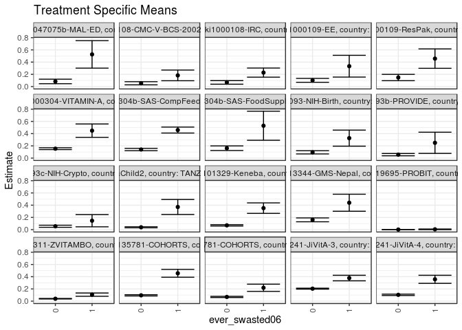

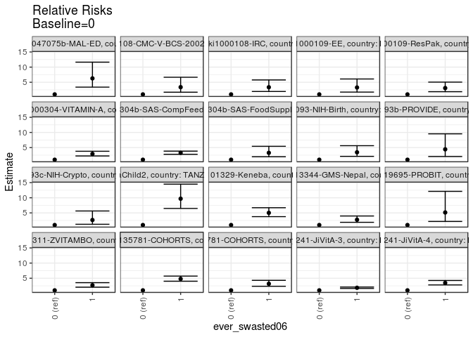

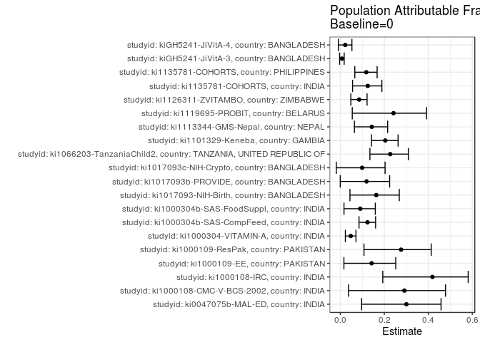

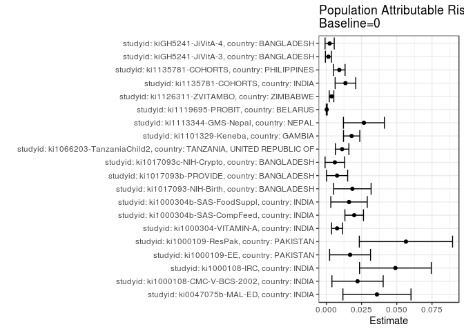

## Results Table

### Parameter: TSM

| studyid | country | intervention_level | baseline_level | estimate | ci_lower | ci_upper |
| --- | --- | --- | --- | --- | --- | --- |
| ki0047075b-MAL-ED | INDIA | 0 | NA | 0.0837209 | 0.0466196 | 0.1208223 |
| ki0047075b-MAL-ED | INDIA | 1 | NA | 0.5263158 | 0.3013228 | 0.7513087 |
| ki1000108-CMC-V-BCS-2002 | INDIA | 0 | NA | 0.0539267 | 0.0283357 | 0.0795177 |
| ki1000108-CMC-V-BCS-2002 | INDIA | 1 | NA | 0.1825696 | 0.0953399 | 0.2697994 |
| ki1000108-IRC | INDIA | 0 | NA | 0.0680447 | 0.0387904 | 0.0972990 |
| ki1000108-IRC | INDIA | 1 | NA | 0.2285946 | 0.1539849 | 0.3032043 |
| ki1000109-EE | PAKISTAN | 0 | NA | 0.1017442 | 0.0697545 | 0.1337339 |
| ki1000109-EE | PAKISTAN | 1 | NA | 0.3333333 | 0.1552817 | 0.5113850 |
| ki1000109-ResPak | PAKISTAN | 0 | NA | 0.1480372 | 0.0962378 | 0.1998365 |
| ki1000109-ResPak | PAKISTAN | 1 | NA | 0.4572809 | 0.2983211 | 0.6162407 |
| ki1000304-VITAMIN-A | INDIA | 0 | NA | 0.1541065 | 0.1390790 | 0.1691339 |
| ki1000304-VITAMIN-A | INDIA | 1 | NA | 0.4487868 | 0.3394318 | 0.5581418 |
| ki1000304b-SAS-CompFeed | INDIA | 0 | NA | 0.1405681 | 0.1213684 | 0.1597678 |
| ki1000304b-SAS-CompFeed | INDIA | 1 | NA | 0.4585729 | 0.4098695 | 0.5072763 |
| ki1000304b-SAS-FoodSuppl | INDIA | 0 | NA | 0.1617251 | 0.1242102 | 0.1992399 |
| ki1000304b-SAS-FoodSuppl | INDIA | 1 | NA | 0.5294118 | 0.2918364 | 0.7669871 |
| ki1017093-NIH-Birth | BANGLADESH | 0 | NA | 0.0947803 | 0.0681088 | 0.1214519 |
| ki1017093-NIH-Birth | BANGLADESH | 1 | NA | 0.3264859 | 0.1951188 | 0.4578530 |
| ki1017093b-PROVIDE | BANGLADESH | 0 | NA | 0.0565068 | 0.0377647 | 0.0752490 |
| ki1017093b-PROVIDE | BANGLADESH | 1 | NA | 0.2500000 | 0.0766194 | 0.4233806 |
| ki1017093c-NIH-Crypto | BANGLADESH | 0 | NA | 0.0548961 | 0.0376882 | 0.0721041 |
| ki1017093c-NIH-Crypto | BANGLADESH | 1 | NA | 0.1458333 | 0.0459189 | 0.2457477 |
| ki1066203-TanzaniaChild2 | TANZANIA, UNITED REPUBLIC OF | 0 | NA | 0.0382415 | 0.0295176 | 0.0469654 |
| ki1066203-TanzaniaChild2 | TANZANIA, UNITED REPUBLIC OF | 1 | NA | 0.3703793 | 0.2474211 | 0.4933375 |
| ki1101329-Keneba | GAMBIA | 0 | NA | 0.0699467 | 0.0589511 | 0.0809424 |
| ki1101329-Keneba | GAMBIA | 1 | NA | 0.3516252 | 0.2660552 | 0.4371953 |
| ki1113344-GMS-Nepal | NEPAL | 0 | NA | 0.1599721 | 0.1286429 | 0.1913014 |
| ki1113344-GMS-Nepal | NEPAL | 1 | NA | 0.4399320 | 0.3005301 | 0.5793339 |
| ki1119695-PROBIT | BELARUS | 0 | NA | 0.0009220 | 0.0001900 | 0.0016540 |
| ki1119695-PROBIT | BELARUS | 1 | NA | 0.0047431 | -0.0002339 | 0.0097201 |
| ki1126311-ZVITAMBO | ZIMBABWE | 0 | NA | 0.0395246 | 0.0352410 | 0.0438082 |
| ki1126311-ZVITAMBO | ZIMBABWE | 1 | NA | 0.1062288 | 0.0793776 | 0.1330801 |
| ki1135781-COHORTS | INDIA | 0 | NA | 0.0952055 | 0.0851713 | 0.1052398 |
| ki1135781-COHORTS | INDIA | 1 | NA | 0.4559754 | 0.3915934 | 0.5203575 |
| ki1135781-COHORTS | PHILIPPINES | 0 | NA | 0.0688050 | 0.0590112 | 0.0785988 |
| ki1135781-COHORTS | PHILIPPINES | 1 | NA | 0.2186430 | 0.1594516 | 0.2778344 |
| kiGH5241-JiVitA-3 | BANGLADESH | 0 | NA | 0.2041844 | 0.1964616 | 0.2119072 |
| kiGH5241-JiVitA-3 | BANGLADESH | 1 | NA | 0.3778596 | 0.3325368 | 0.4231825 |
| kiGH5241-JiVitA-4 | BANGLADESH | 0 | NA | 0.1035195 | 0.0921891 | 0.1148500 |
| kiGH5241-JiVitA-4 | BANGLADESH | 1 | NA | 0.3572647 | 0.2912523 | 0.4232771 |

### Parameter: E(Y)

| studyid | country | intervention_level | baseline_level | estimate | ci_lower | ci_upper |
| --- | --- | --- | --- | --- | --- | --- |
| ki0047075b-MAL-ED | INDIA | NA | NA | 0.1196581 | 0.0779840 | 0.1613323 |
| ki1000108-CMC-V-BCS-2002 | INDIA | NA | NA | 0.0760870 | 0.0489610 | 0.1032130 |
| ki1000108-IRC | INDIA | NA | NA | 0.1170732 | 0.0859146 | 0.1482317 |
| ki1000109-EE | PAKISTAN | NA | NA | 0.1185984 | 0.0856546 | 0.1515422 |
| ki1000109-ResPak | PAKISTAN | NA | NA | 0.2045455 | 0.1511224 | 0.2579685 |
| ki1000304-VITAMIN-A | INDIA | NA | NA | 0.1617391 | 0.1466878 | 0.1767905 |
| ki1000304b-SAS-CompFeed | INDIA | NA | NA | 0.1603563 | 0.1395035 | 0.1812092 |
| ki1000304b-SAS-FoodSuppl | INDIA | NA | NA | 0.1778351 | 0.1397389 | 0.2159312 |
| ki1017093-NIH-Birth | BANGLADESH | NA | NA | 0.1132813 | 0.0858017 | 0.1407608 |
| ki1017093b-PROVIDE | BANGLADESH | NA | NA | 0.0641447 | 0.0446535 | 0.0836359 |
| ki1017093c-NIH-Crypto | BANGLADESH | NA | NA | 0.0609418 | 0.0434802 | 0.0784034 |
| ki1066203-TanzaniaChild2 | TANZANIA, UNITED REPUBLIC OF | NA | NA | 0.0494534 | 0.0397554 | 0.0591514 |
| ki1101329-Keneba | GAMBIA | NA | NA | 0.0879121 | 0.0760335 | 0.0997906 |
| ki1113344-GMS-Nepal | NEPAL | NA | NA | 0.1866438 | 0.1550166 | 0.2182711 |
| ki1119695-PROBIT | BELARUS | NA | NA | 0.0012159 | 0.0002433 | 0.0021885 |
| ki1126311-ZVITAMBO | ZIMBABWE | NA | NA | 0.0432128 | 0.0388939 | 0.0475316 |
| ki1135781-COHORTS | INDIA | NA | NA | 0.1087695 | 0.1008135 | 0.1167256 |
| ki1135781-COHORTS | PHILIPPINES | NA | NA | 0.0780116 | 0.0679971 | 0.0880261 |
| kiGH5241-JiVitA-3 | BANGLADESH | NA | NA | 0.2056528 | 0.1980793 | 0.2132263 |
| kiGH5241-JiVitA-4 | BANGLADESH | NA | NA | 0.1058706 | 0.0951082 | 0.1166330 |

### Parameter: RR

| studyid | country | intervention_level | baseline_level | estimate | ci_lower | ci_upper |
| --- | --- | --- | --- | --- | --- | --- |
| ki0047075b-MAL-ED | INDIA | 0 | 0 | 1.000000 | 1.000000 | 1.000000 |
| ki0047075b-MAL-ED | INDIA | 1 | 0 | 6.286550 | 3.396264 | 11.636523 |
| ki1000108-CMC-V-BCS-2002 | INDIA | 0 | 0 | 1.000000 | 1.000000 | 1.000000 |
| ki1000108-CMC-V-BCS-2002 | INDIA | 1 | 0 | 3.385514 | 1.721331 | 6.658630 |
| ki1000108-IRC | INDIA | 0 | 0 | 1.000000 | 1.000000 | 1.000000 |
| ki1000108-IRC | INDIA | 1 | 0 | 3.359476 | 1.956433 | 5.768703 |
| ki1000109-EE | PAKISTAN | 0 | 0 | 1.000000 | 1.000000 | 1.000000 |
| ki1000109-EE | PAKISTAN | 1 | 0 | 3.276190 | 1.762725 | 6.089107 |
| ki1000109-ResPak | PAKISTAN | 0 | 0 | 1.000000 | 1.000000 | 1.000000 |
| ki1000109-ResPak | PAKISTAN | 1 | 0 | 3.088960 | 1.889503 | 5.049833 |
| ki1000304-VITAMIN-A | INDIA | 0 | 0 | 1.000000 | 1.000000 | 1.000000 |
| ki1000304-VITAMIN-A | INDIA | 1 | 0 | 2.912187 | 2.239663 | 3.786656 |
| ki1000304b-SAS-CompFeed | INDIA | 0 | 0 | 1.000000 | 1.000000 | 1.000000 |
| ki1000304b-SAS-CompFeed | INDIA | 1 | 0 | 3.262282 | 2.779958 | 3.828289 |
| ki1000304b-SAS-FoodSuppl | INDIA | 0 | 0 | 1.000000 | 1.000000 | 1.000000 |
| ki1000304b-SAS-FoodSuppl | INDIA | 1 | 0 | 3.273529 | 1.975274 | 5.425068 |
| ki1017093-NIH-Birth | BANGLADESH | 0 | 0 | 1.000000 | 1.000000 | 1.000000 |
| ki1017093-NIH-Birth | BANGLADESH | 1 | 0 | 3.444658 | 2.107666 | 5.629768 |
| ki1017093b-PROVIDE | BANGLADESH | 0 | 0 | 1.000000 | 1.000000 | 1.000000 |
| ki1017093b-PROVIDE | BANGLADESH | 1 | 0 | 4.424242 | 2.051034 | 9.543441 |
| ki1017093c-NIH-Crypto | BANGLADESH | 0 | 0 | 1.000000 | 1.000000 | 1.000000 |
| ki1017093c-NIH-Crypto | BANGLADESH | 1 | 0 | 2.656531 | 1.250558 | 5.643210 |
| ki1066203-TanzaniaChild2 | TANZANIA, UNITED REPUBLIC OF | 0 | 0 | 1.000000 | 1.000000 | 1.000000 |
| ki1066203-TanzaniaChild2 | TANZANIA, UNITED REPUBLIC OF | 1 | 0 | 9.685269 | 6.473353 | 14.490856 |
| ki1101329-Keneba | GAMBIA | 0 | 0 | 1.000000 | 1.000000 | 1.000000 |
| ki1101329-Keneba | GAMBIA | 1 | 0 | 5.027042 | 3.765684 | 6.710906 |
| ki1113344-GMS-Nepal | NEPAL | 0 | 0 | 1.000000 | 1.000000 | 1.000000 |
| ki1113344-GMS-Nepal | NEPAL | 1 | 0 | 2.750054 | 1.895928 | 3.988967 |
| ki1119695-PROBIT | BELARUS | 0 | 0 | 1.000000 | 1.000000 | 1.000000 |
| ki1119695-PROBIT | BELARUS | 1 | 0 | 5.144212 | 2.183254 | 12.120863 |
| ki1126311-ZVITAMBO | ZIMBABWE | 0 | 0 | 1.000000 | 1.000000 | 1.000000 |
| ki1126311-ZVITAMBO | ZIMBABWE | 1 | 0 | 2.687663 | 2.041702 | 3.537994 |
| ki1135781-COHORTS | INDIA | 0 | 0 | 1.000000 | 1.000000 | 1.000000 |
| ki1135781-COHORTS | INDIA | 1 | 0 | 4.789380 | 4.018051 | 5.708778 |
| ki1135781-COHORTS | PHILIPPINES | 0 | 0 | 1.000000 | 1.000000 | 1.000000 |
| ki1135781-COHORTS | PHILIPPINES | 1 | 0 | 3.177720 | 2.341535 | 4.312515 |
| kiGH5241-JiVitA-3 | BANGLADESH | 0 | 0 | 1.000000 | 1.000000 | 1.000000 |
| kiGH5241-JiVitA-3 | BANGLADESH | 1 | 0 | 1.850580 | 1.633997 | 2.095872 |
| kiGH5241-JiVitA-4 | BANGLADESH | 0 | 0 | 1.000000 | 1.000000 | 1.000000 |
| kiGH5241-JiVitA-4 | BANGLADESH | 1 | 0 | 3.451182 | 2.793368 | 4.263905 |

### Parameter: PAR

| studyid | country | intervention_level | baseline_level | estimate | ci_lower | ci_upper |
| --- | --- | --- | --- | --- | --- | --- |
| ki0047075b-MAL-ED | INDIA | 0 | NA | 0.0359372 | 0.0117760 | 0.0600983 |
| ki1000108-CMC-V-BCS-2002 | INDIA | 0 | NA | 0.0221602 | 0.0039700 | 0.0403505 |
| ki1000108-IRC | INDIA | 0 | NA | 0.0490285 | 0.0235671 | 0.0744898 |
| ki1000109-EE | PAKISTAN | 0 | NA | 0.0168542 | 0.0023317 | 0.0313767 |
| ki1000109-ResPak | PAKISTAN | 0 | NA | 0.0565083 | 0.0234108 | 0.0896058 |
| ki1000304-VITAMIN-A | INDIA | 0 | NA | 0.0076327 | 0.0037078 | 0.0115575 |
| ki1000304b-SAS-CompFeed | INDIA | 0 | NA | 0.0197882 | 0.0131902 | 0.0263862 |
| ki1000304b-SAS-FoodSuppl | INDIA | 0 | NA | 0.0161100 | 0.0031765 | 0.0290435 |
| ki1017093-NIH-Birth | BANGLADESH | 0 | NA | 0.0185009 | 0.0052277 | 0.0317741 |
| ki1017093b-PROVIDE | BANGLADESH | 0 | NA | 0.0076379 | 0.0001298 | 0.0151459 |
| ki1017093c-NIH-Crypto | BANGLADESH | 0 | NA | 0.0060457 | -0.0008945 | 0.0129859 |
| ki1066203-TanzaniaChild2 | TANZANIA, UNITED REPUBLIC OF | 0 | NA | 0.0112119 | 0.0064110 | 0.0160128 |
| ki1101329-Keneba | GAMBIA | 0 | NA | 0.0179653 | 0.0121925 | 0.0237382 |
| ki1113344-GMS-Nepal | NEPAL | 0 | NA | 0.0266717 | 0.0121391 | 0.0412042 |
| ki1119695-PROBIT | BELARUS | 0 | NA | 0.0002939 | -0.0000417 | 0.0006294 |
| ki1126311-ZVITAMBO | ZIMBABWE | 0 | NA | 0.0036882 | 0.0020571 | 0.0053192 |
| ki1135781-COHORTS | INDIA | 0 | NA | 0.0135640 | 0.0062550 | 0.0208730 |
| ki1135781-COHORTS | PHILIPPINES | 0 | NA | 0.0092066 | 0.0051149 | 0.0132983 |
| kiGH5241-JiVitA-3 | BANGLADESH | 0 | NA | 0.0014684 | -0.0006653 | 0.0036021 |
| kiGH5241-JiVitA-4 | BANGLADESH | 0 | NA | 0.0023511 | -0.0009033 | 0.0056056 |

### Parameter: PAF

| studyid | country | intervention_level | baseline_level | estimate | ci_lower | ci_upper |
| --- | --- | --- | --- | --- | --- | --- |
| ki0047075b-MAL-ED | INDIA | 0 | NA | 0.3003322 | 0.0968199 | 0.4579874 |
| ki1000108-CMC-V-BCS-2002 | INDIA | 0 | NA | 0.2912490 | 0.0369546 | 0.4783964 |
| ki1000108-IRC | INDIA | 0 | NA | 0.4187847 | 0.1929615 | 0.5814187 |
| ki1000109-EE | PAKISTAN | 0 | NA | 0.1421115 | 0.0162356 | 0.2518812 |
| ki1000109-ResPak | PAKISTAN | 0 | NA | 0.2762628 | 0.1074340 | 0.4131576 |
| ki1000304-VITAMIN-A | INDIA | 0 | NA | 0.0471913 | 0.0228212 | 0.0709536 |
| ki1000304b-SAS-CompFeed | INDIA | 0 | NA | 0.1234015 | 0.0848440 | 0.1603344 |
| ki1000304b-SAS-FoodSuppl | INDIA | 0 | NA | 0.0905895 | 0.0165935 | 0.1590177 |
| ki1017093-NIH-Birth | BANGLADESH | 0 | NA | 0.1633183 | 0.0437036 | 0.2679715 |
| ki1017093b-PROVIDE | BANGLADESH | 0 | NA | 0.1190727 | -0.0003859 | 0.2242665 |
| ki1017093c-NIH-Crypto | BANGLADESH | 0 | NA | 0.0992042 | -0.0185911 | 0.2033770 |
| ki1066203-TanzaniaChild2 | TANZANIA, UNITED REPUBLIC OF | 0 | NA | 0.2267164 | 0.1344284 | 0.3091646 |
| ki1101329-Keneba | GAMBIA | 0 | NA | 0.2043558 | 0.1415051 | 0.2626051 |
| ki1113344-GMS-Nepal | NEPAL | 0 | NA | 0.1429015 | 0.0639375 | 0.2152043 |
| ki1119695-PROBIT | BELARUS | 0 | NA | 0.2416820 | 0.0541509 | 0.3920318 |
| ki1126311-ZVITAMBO | ZIMBABWE | 0 | NA | 0.0853487 | 0.0476893 | 0.1215188 |
| ki1135781-COHORTS | INDIA | 0 | NA | 0.1247042 | 0.0555527 | 0.1887924 |
| ki1135781-COHORTS | PHILIPPINES | 0 | NA | 0.1180159 | 0.0658244 | 0.1672916 |
| kiGH5241-JiVitA-3 | BANGLADESH | 0 | NA | 0.0071403 | -0.0032742 | 0.0174466 |
| kiGH5241-JiVitA-4 | BANGLADESH | 0 | NA | 0.0222075 | -0.0091711 | 0.0526104 |